# Analytics Dashboard: Defect Risks & Scrap Costs

KPIs

Defects

Scrap Costs

Parts Inspected

Defects

Defect Rate

Scrapped Parts

Total Scrap Cost

Cost / Scrap Event

Weekly

868 ▲ 28.8%

Current

674

Prior

47 ▼ 6.0%

Current

50

Prior

5.4% ▼ 27.0%

Current

7.4%

Prior

18 ▼ 0.0%

Current

18

Prior

$4K ▲ 8.2%

Current

$4K

Prior

$140 ▼ 11.1%

Current

$158

Prior

Monthly

3,335 ▲ 1.7%

Current

3,280

Prior

220 ▲ 20.9%

Current

182

Prior

6.6% ▲ 18.9%

Current

5.5%

Prior

89 ▲ 45.9%

Current

61

Prior

$19K ▲ 65.9%

Current

$11K

Prior

$175 ▲ 56.6%

Current

$111

Prior

Trailing 12M

43,348 ▲ 1.9%

Current

42,547

Prior

2,545 ▼ 1.0%

Current

2,572

Prior

5.9% ▼ 2.9%

Current

6.0%

Prior

941 ▲ 0.9%

Current

933

Prior

$184K ▲ 1.7%

Current

$181K

Prior

$136 ▼ 1.4%

Current

$138

Prior

Trend Charts (Trailing 12 Months)

Defects

Defect Rate

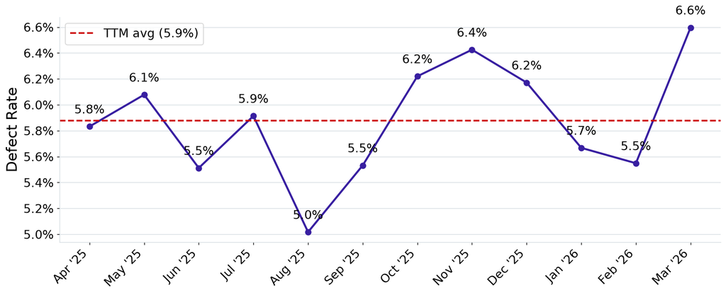

Defect Rate by Part Complexity

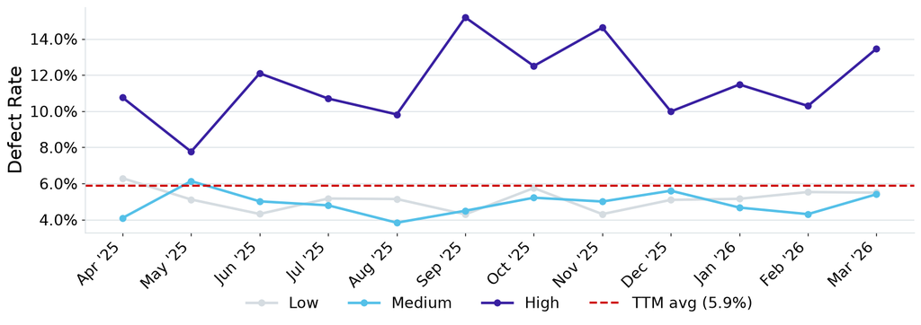

Defect Rate by Supplier

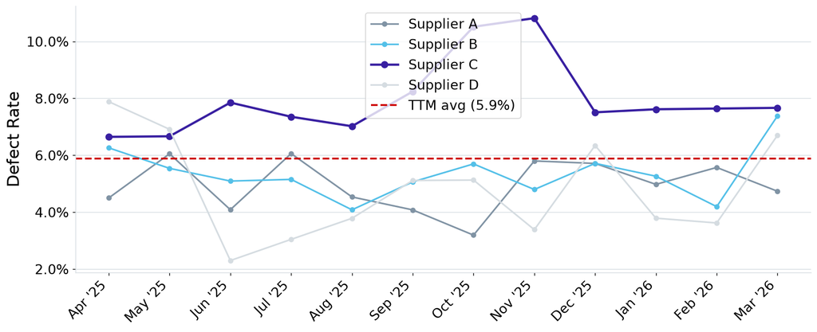

Defects by Machine Type

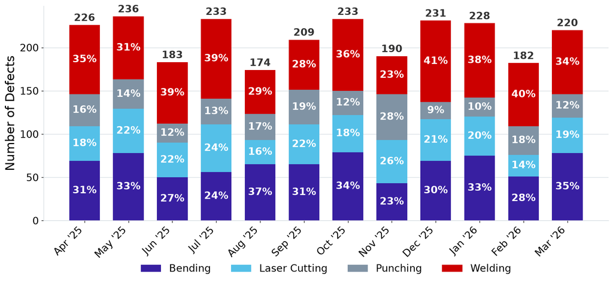

Scrap Costs

Total Scrap Cost

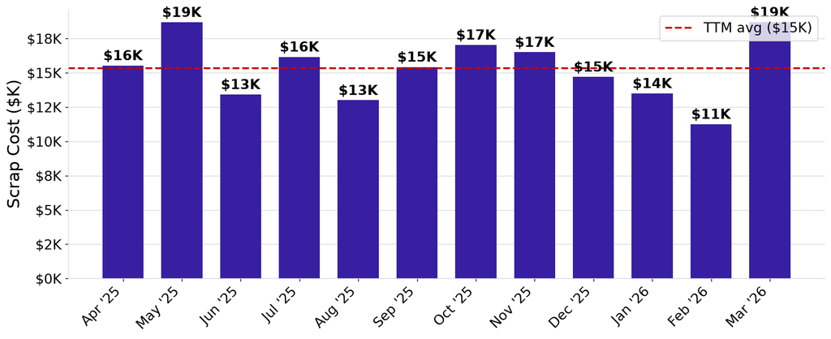

Scrap Cost by Reason

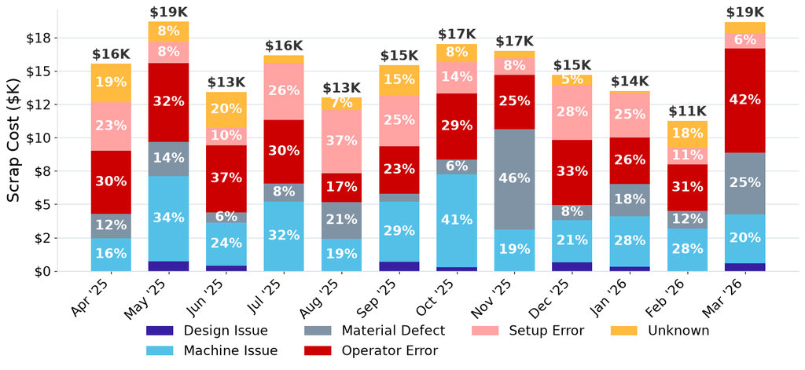

Scrap Cost by Machine Type

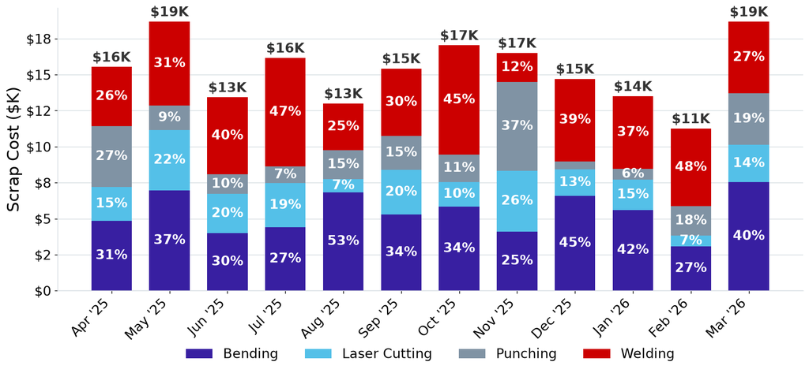

Scrap Cost, as % Material vs. Labor

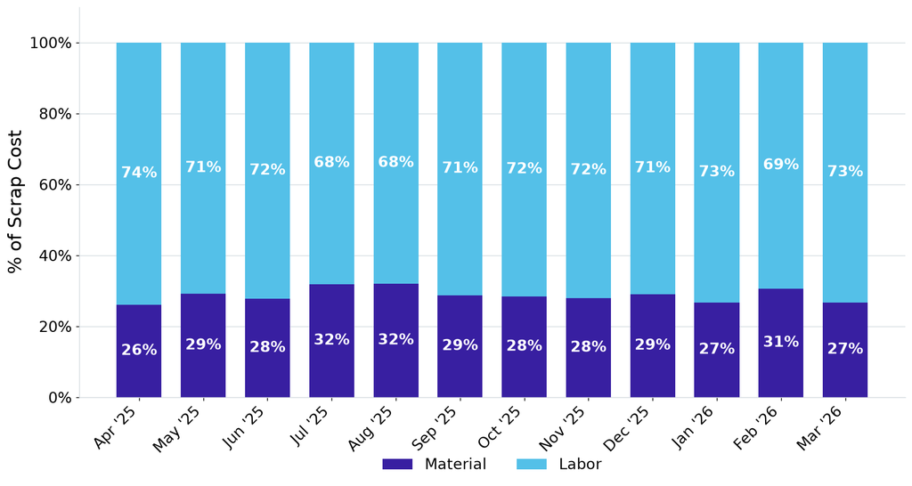